# Task3

2022-11-11

# Предварительный анализ данных.

Описание признаков присутствует в сопроводительном файле. Прочитаем данные. Среди данных не может быть отрицательных значений, NA обозначаются как -999.

```r
library(readxl)
library(dplyr)
library(tidyr)
```

```r
df <- read_excel("Sleep/SLEEP_shortname.xls")
df[df < 0] <- NA

head(df)
```

```
## # A tibble: 6 × 11
##   NAME     BODY_…¹ BRAIN…² SLOWW…³ PARADOX SLEEP LIFES…⁴ GESTT…⁵ PRED_…⁶ EXP_IND
##   <chr>      <dbl>   <dbl>   <dbl>   <dbl> <dbl>   <dbl>   <dbl>   <dbl>   <dbl>
## 1 African… 6654     5712      NA      NA     3.3    38.6     645       3       5
## 2 African…    1        6.6     6.3     2     8.3     4.5      42       3       1
## 3 Arctic …    3.38    44.5    NA      NA    12.5    14        60       1       1
## 4 Arc. gr…    0.92     5.7    NA      NA    16.5    NA        25       5       2
## 5 Asian e… 2547     4603       2.1     1.8   3.9    69       624       3       5
## 6 Baboon     10.6    180.      9.1     0.7   9.8    27       180       4       4
## # … with 1 more variable: DANG_IND <dbl>, and abbreviated variable names
## #   ¹BODY_WEI, ²BRAIN_WE, ³SLOWWAVE, ⁴LIFESPAN, ⁵GESTTIME, ⁶PRED_IND
## # ℹ Use `colnames()` to see all variable names
```

Признаков немного, поэтому рассматривать будем все.

Кроме индексов-факторов, все признаки количественные. Индексы - порядковые признаки. Все количественные признаки непрерывные, но можно заметить дискретизацию при округлении. Проверим это, посмотрев на частоты мод

```r
mode_rate <- function(x) {
  x <- x[!is.na(x)]
  u <- unique(x)
  tab <- tabulate(match(x, u))
  max(tab) / length(x)
}
```

Отношение частоты моды к числу элементов.

```r
df %>% summarise(BODY_WEI = round(mode_rate(BODY_WEI), 3), BRAIN_WE = round(mode_rate(BRAIN_WE), 3),
                SLOWWAVE = round(mode_rate(SLOWWAVE), 3), PARADOX = round(mode_rate(PARADOX), 3),
                SLEEP = round(mode_rate(SLEEP), 3), LIFESPAN = round(mode_rate(LIFESPAN), 3),
                GESTTIME = round(mode_rate(GESTTIME), 3))
```

```
## # A tibble: 1 × 7
##   BODY_WEI BRAIN_WE SLOWWAVE PARADOX SLEEP LIFESPAN GESTTIME
##      <dbl>    <dbl>    <dbl>   <dbl> <dbl>    <dbl>    <dbl>
## 1    0.032    0.032    0.062    0.06 0.052    0.052    0.052
```

Дискретизация есть, будем иметь это в виду, когда нужно будет применять критерии, для которых важна непрерывность признаков.

Посмотрим на данные.

```r
library(ggplot2)
library(GGally)
```

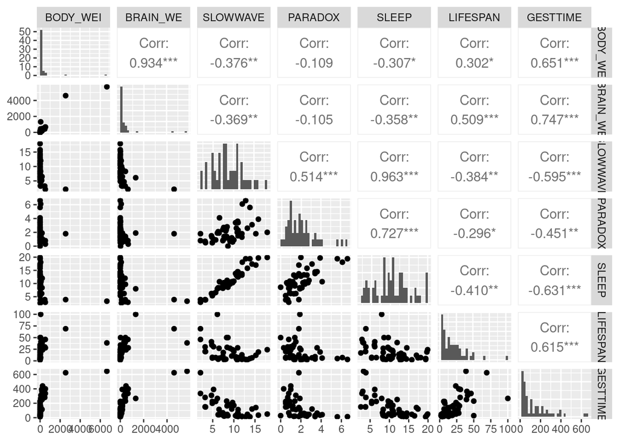

```r
df %>% dplyr::select(-NAME) %>%
  ggpairs(diag=list(continuous = "barDiag"),
          columns = c("BODY_WEI", "BRAIN_WE", "SLOWWAVE", "PARADOX", "SLEEP", "LIFESPAN", "GESTTIME"))
```

Преобразуем данные. Логарифмируем данные, чтобы было легче наблюдать корреляции (выше заметны сильно отличающиеся индивиды, это слоны) и получить нормальные распределения признаков. Факторизуем индексы.

```r
dfNew <- df %>%
  mutate(PRED_IND = as.factor(PRED_IND), EXP_IND = as.factor(EXP_IND),
         DANG_IND = as.factor(DANG_IND),
         BODY_WEI.log = log(BODY_WEI), BRAIN_WE.log = log(BRAIN_WE),
         LIFESPAN.log = log(LIFESPAN), GESTTIME.log = log(GESTTIME))
```

Посмотрим на новые данные.

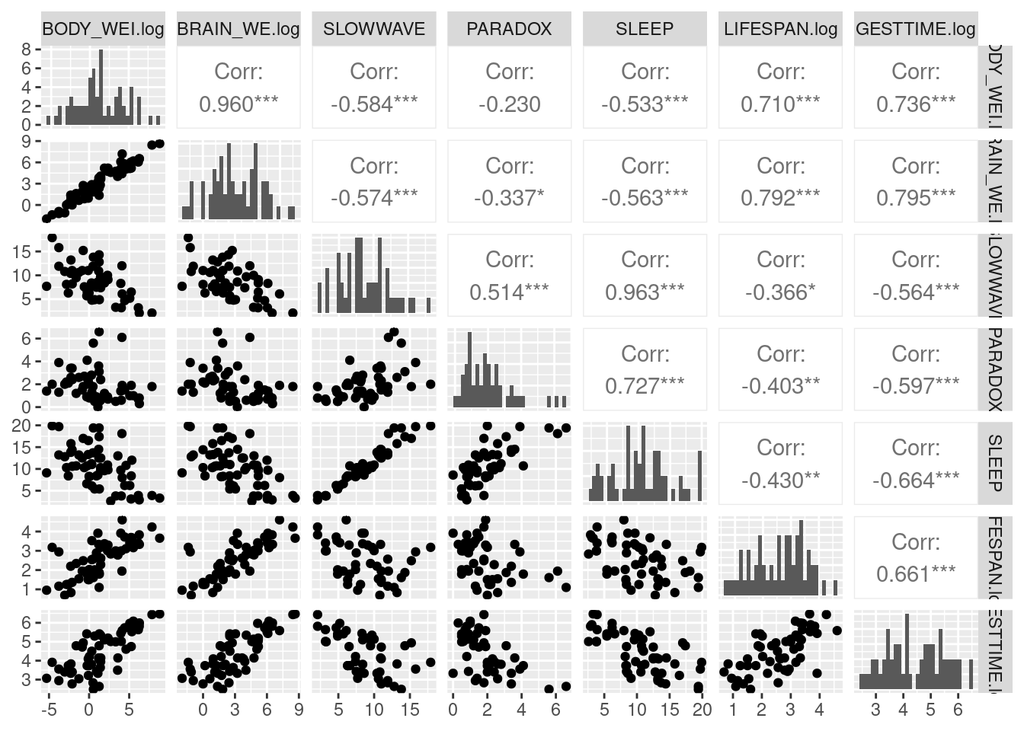

```r
dfNew %>% dplyr::select(-NAME) %>%
  ggpairs(diag=list(continuous = "barDiag"),
          columns = c("BODY_WEI.log", "BRAIN_WE.log", "SLOWWAVE", "PARADOX", "SLEEP", "LIFESPAN.log", "GESTTIME.log"))
```

Используем описательные статистики для распределений признаков в новой выборке.

```r
library(moments)
```

```r
characteristics <- function(x) {
  c(mean = round(mean(x, na.rm = TRUE), 3),
    median = round(median(x, na.rm = TRUE), 3),
    var = round(var(x, na.rm = TRUE), 3),
    skewness = round(skewness(x, na.rm = TRUE), 3),
    kurtosis = round(kurtosis(x, na.rm = TRUE) - 3, 3))
}

data.frame(lapply(as.list(dfNew[2:8]), characteristics)) %>% t()
```

```
##             mean median        var skewness kurtosis
## BODY_WEI 198.790  3.342 808485.128    6.404   42.039
## BRAIN_WE 283.134 17.250 865418.910    4.948   24.104
## SLOWWAVE   8.673  8.350     13.443    0.289   -0.334
## PARADOX    1.972  1.800      2.081    1.409    1.976
## SLEEP     10.533 10.450     21.222    0.196   -0.567
## LIFESPAN  19.878 15.100    331.468    1.961    5.288
## GESTTIME 142.353 79.000  21551.719    1.640    2.511
```

# Регрессионный анализ данных.

1. Для начала проверим корреляционную матрицу, чтобы убедится в том, что у нас нет линейно зависимых признаков.

```r
dfNew.num <- dfNew %>%
  mutate(PRED_IND = as.numeric(PRED_IND), EXP_IND = as.numeric(EXP_IND),
         DANG_IND = as.numeric(DANG_IND))

cor(x=dfNew.num %>% dplyr::select(-NAME) %>%
      mutate(SLOWWAVE_PARADOX=SLOWWAVE+PARADOX),
    use="pairwise.complete.obs")
```

```
##                     BODY_WEI    BRAIN_WE   SLOWWAVE    PARADOX      SLEEP
## BODY_WEI          1.00000000  0.93416384 -0.3759462 -0.1093833 -0.3071859
## BRAIN_WE          0.93416384  1.00000000 -0.3692177 -0.1051388 -0.3581020
## SLOWWAVE         -0.37594625 -0.36921766  1.0000000  0.5142539  0.9627147
## PARADOX          -0.10938331 -0.10513879  0.5142539  1.0000000  0.7270870
## SLEEP            -0.30718591 -0.35810203  0.9627147  0.7270870  1.0000000
## LIFESPAN          0.30245056  0.50925268 -0.3844318 -0.2957453 -0.4102024
## GESTTIME          0.65110218  0.74724248 -0.5947028 -0.4508987 -0.6313262
## PRED_IND          0.05949472  0.03385548 -0.3181846 -0.4474705 -0.3958350
## EXP_IND           0.33827367  0.36780037 -0.5437566 -0.5372245 -0.6422845
## DANG_IND          0.13358123  0.14587888 -0.4838522 -0.5793365 -0.5877424
## BODY_WEI.log      0.46147513  0.54049751 -0.5841538 -0.2295718 -0.5328345
## BRAIN_WE.log      0.43849122  0.54632681 -0.5737692 -0.3366790 -0.5625958
## LIFESPAN.log      0.27716912  0.40359982 -0.3662981 -0.4031934 -0.4299409
## GESTTIME.log      0.39382962  0.48508871 -0.5637449 -0.5968043 -0.6636560
## SLOWWAVE_PARADOX -0.32569922 -0.32217479  0.9627147  0.7270870  1.0000000
##                     LIFESPAN   GESTTIME    PRED_IND    EXP_IND    DANG_IND
## BODY_WEI          0.30245056  0.6511022  0.05949472  0.3382737  0.13358123
## BRAIN_WE          0.50925268  0.7472425  0.03385548  0.3678004  0.14587888
## SLOWWAVE         -0.38443179 -0.5947028 -0.31818462 -0.5437566 -0.48385220
## PARADOX          -0.29574535 -0.4508987 -0.44747050 -0.5372245 -0.57933653
## SLEEP            -0.41020239 -0.6313262 -0.39583497 -0.6422845 -0.58774241
## LIFESPAN          1.00000000  0.6148488 -0.10254416  0.3603522  0.06177846
## GESTTIME          0.61484879  1.0000000  0.20050426  0.6382790  0.37861701
## PRED_IND         -0.10254416  0.2005043  1.00000000  0.6182460  0.91604245
## EXP_IND           0.36035221  0.6382790  0.61824597  1.0000000  0.78720311
## DANG_IND          0.06177846  0.3786170  0.91604245  0.7872031  1.00000000
## BODY_WEI.log      0.61422182  0.7674432  0.12325054  0.6506388  0.32271242
## BRAIN_WE.log      0.70503917  0.7802754  0.08321878  0.6327438  0.28803574
## LIFESPAN.log      0.87474169  0.6134696 -0.05168501  0.5215378  0.15482147
## GESTTIME.log      0.58194880  0.8895708  0.15546799  0.6285366  0.36268484
## SLOWWAVE_PARADOX -0.39760925 -0.6086120 -0.38656427 -0.5970194 -0.56347767
##                  BODY_WEI.log BRAIN_WE.log LIFESPAN.log GESTTIME.log
## BODY_WEI            0.4614751   0.43849122   0.27716912    0.3938296
## BRAIN_WE            0.5404975   0.54632681   0.40359982    0.4850887
## SLOWWAVE           -0.5841538  -0.57376921  -0.36629806   -0.5637449
## PARADOX            -0.2295718  -0.33667895  -0.40319343   -0.5968043
## SLEEP              -0.5328345  -0.56259577  -0.42994087   -0.6636560
## LIFESPAN            0.6142218   0.70503917   0.87474169    0.5819488
## GESTTIME            0.7674432   0.78027542   0.61346958    0.8895708
```

[output cut: 9 more lines]

```
## BODY_WEI               -0.3256992
## BRAIN_WE               -0.3221748
## SLOWWAVE                0.9627147
## PARADOX                 0.7270870
## SLEEP                   1.0000000
## LIFESPAN               -0.3976092
## GESTTIME               -0.6086120
## PRED_IND               -0.3865643
## EXP_IND                -0.5970194
## DANG_IND               -0.5634777
## BODY_WEI.log           -0.5241171
## BRAIN_WE.log           -0.5536697
## LIFESPAN.log           -0.4136177
## GESTTIME.log           -0.6305837
## SLOWWAVE_PARADOX        1.0000000
```

Можно увидеть, что SLEEP линейно зависима с SLOWWAVE+PARADOX. Обрающаю внимание, что для использования lm.beta нужно сделать независимые переменные независимыми. В нашем случаем нужно удалить SLEEP, SLOWWAVE или PARADOX из модели. Так как в SLOWWAVE и PARADOX много пропусков, удалим их обоих. Так же многие методы, связанные с регрессией, требуют отстутствия пропусков в данных, поэтому удалим пропуски из выборки.

```r
dfNew.o.dum <- dfNew %>% dplyr::select(-SLOWWAVE, -PARADOX) %>% na.omit()
dfNew.o.num <- dfNew.num %>% dplyr::select(-SLOWWAVE, -PARADOX) %>% na.omit()
```

Посмотрим сколько было индивидов в выборке до и после удаления.

```r
c(nrow(dfNew), nrow(dfNew.o.num))
```

```
## [1] 62 51
```

Посмотрим кого удалили.

```r
dfNew[dfNew$NAME %in% dfNew.o.num$NAME == FALSE,]$NAME
```

```
##  [1] "Arc. ground squirrel" "Desert hedgehog"      "Genet"
##  [4] "Giant armadillo"      "Giraffe"              "Kangaroo"
##  [7] "Mole rat"             "Mountain beaver"      "Okapi"
## [10] "Star nosed mole"      "Yellow-bell. marmot"
```

Американский суслик, эфиопский ёж, генеты, броненосец, жираф, кенгуру, землекоп, горный бобр, окапи, крот, желтобрюхий сурок. Тут представлены довольно различне животные: большие, стредние, маленькие, тровоядные, хищные и т.д. Поэтому нельзя сказать, что при удалении индивидов с пропусками мы удалили связанную между собой группу или что пропуски отражают какую-то свзяь между индивидами, а мы ее не будем далее рассматривать.

Посмотрим на новые данные.

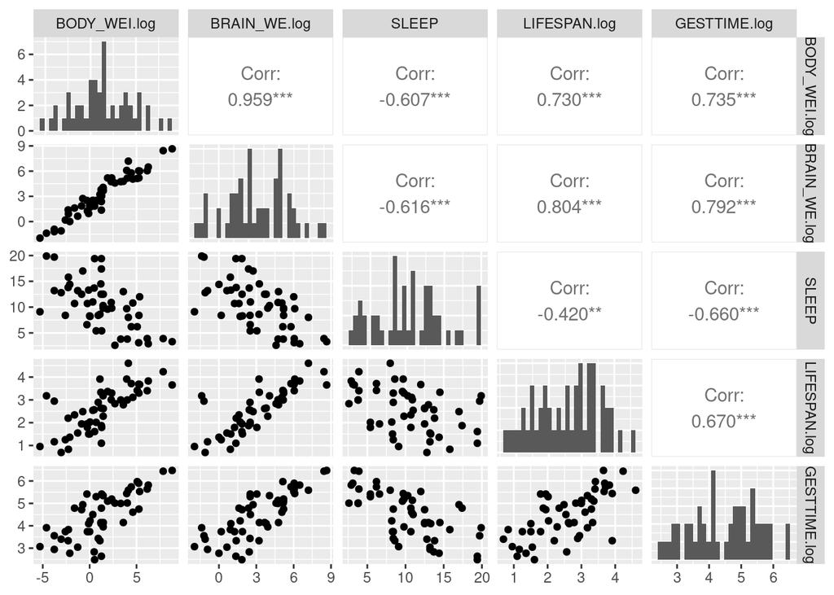

```r
dfNew.o.num %>% dplyr::select(-NAME) %>%
  ggpairs(diag=list(continuous = "barDiag"),
          columns = c("BODY_WEI.log", "BRAIN_WE.log", "SLEEP", "LIFESPAN.log", "GESTTIME.log"))
```

2,3. Будем исследовать зависимость продолжительности жизни (зависимая переменная) от остальных признаков (независиммые переменные).

Построим линейную регрессионную модель c dummy variables и без них и вычислим стандартизированные коэффициенты.

```r
library(lm.beta)

model1.num = lm(LIFESPAN.log~BODY_WEI.log+BRAIN_WE.log+SLEEP+GESTTIME.log+PRED_IND+EXP_IND+DANG_IND,
                data=dfNew.o.num)
model1.num.beta <- lm.beta(model1.num)
summary(model1.num.beta)
```

```
##
## Call:
## lm(formula = LIFESPAN.log ~ BODY_WEI.log + BRAIN_WE.log + SLEEP +
##     GESTTIME.log + PRED_IND + EXP_IND + DANG_IND, data = dfNew.o.num)
##
## Residuals:
##     Min      1Q  Median      3Q     Max
## -1.1467 -0.3182 -0.1158  0.2629  1.2773
##
## Coefficients:
##               Estimate Standardized Std. Error t value Pr(>|t|)
## (Intercept)   0.799078           NA   0.791856   1.009  0.31856
## BODY_WEI.log -0.173028    -0.567989   0.087305  -1.982  0.05391 .
## BRAIN_WE.log  0.457224     1.195428   0.119835   3.815  0.00043 ***
## SLEEP         0.042986     0.208040   0.029444   1.460  0.15158
## GESTTIME.log -0.005851    -0.006312   0.135615  -0.043  0.96578
## PRED_IND     -0.499102    -0.768230   0.190067  -2.626  0.01192 *
## EXP_IND       0.167685     0.273804   0.111090   1.509  0.13850
## DANG_IND      0.437544     0.646092   0.245690   1.781  0.08200 .
## ---
## Signif. codes:  0 '***' 0.001 '**' 0.01 '*' 0.05 '.' 0.1 ' ' 1
##
## Residual standard error: 0.5296 on 43 degrees of freedom
## Multiple R-squared:  0.742,  Adjusted R-squared:    0.7
## F-statistic: 17.67 on 7 and 43 DF,  p-value: 8.626e-11
```

```r
model1.dum = lm(LIFESPAN.log~BODY_WEI.log+BRAIN_WE.log+SLEEP+GESTTIME.log+PRED_IND+EXP_IND+DANG_IND,
                data=dfNew.o.dum)
model1.dum.beta <- lm.beta(model1.dum)
summary(model1.dum.beta)
```

```
##
## Call:
## lm(formula = LIFESPAN.log ~ BODY_WEI.log + BRAIN_WE.log + SLEEP +
##     GESTTIME.log + PRED_IND + EXP_IND + DANG_IND, data = dfNew.o.dum)
##
## Residuals:
##      Min       1Q   Median       3Q      Max
## -0.74520 -0.21437 -0.03226  0.14726  1.49852
##
## Coefficients:
##               Estimate Standardized Std. Error t value Pr(>|t|)
## (Intercept)   0.793268           NA   0.768101   1.033 0.309004
## BODY_WEI.log -0.086533    -0.284057   0.100607  -0.860 0.395753
## BRAIN_WE.log  0.381844     0.998344   0.122057   3.128 0.003594 **
## SLEEP         0.077778     0.376424   0.033178   2.344 0.025045 *
## GESTTIME.log  0.025352     0.027349   0.133350   0.190 0.850349
## PRED_IND2    -1.430240    -0.651068   0.399221  -3.583 0.001052 **
## PRED_IND3    -2.453107    -0.931858   0.587990  -4.172 0.000197 ***
## PRED_IND4    -2.517351    -0.904843   0.732629  -3.436 0.001574 **
## PRED_IND5    -2.692798    -1.156869   0.774120  -3.479 0.001401 **
## EXP_IND2      0.058020     0.024926   0.250382   0.232 0.818141
## EXP_IND3      0.287289     0.080677   0.360377   0.797 0.430872
## EXP_IND4     -0.011100    -0.003448   0.414491  -0.027 0.978792
## EXP_IND5      0.592680     0.245791   0.535969   1.106 0.276572
## DANG_IND2     1.105042     0.489616   0.446892   2.473 0.018567 *
## DANG_IND3     1.841632     0.699578   0.675053   2.728 0.010007 *
## DANG_IND4     2.301072     0.916284   0.807778   2.849 0.007401 **
## DANG_IND5     2.507402     0.901267   1.019064   2.460 0.019111 *
## ---
## Signif. codes:  0 '***' 0.001 '**' 0.01 '*' 0.05 '.' 0.1 ' ' 1
##
## Residual standard error: 0.4904 on 34 degrees of freedom
## Multiple R-squared:  0.825,  Adjusted R-squared:  0.7427
## F-statistic: 10.02 on 16 and 34 DF,  p-value: 1.322e-08
```

Далее будем работать с данными без dummy variables так как модель без них более значима, p-value: 8.626e-11. Среди переменных значимы BRAIN_WE.log с уровнем значимости 0.001, PRED_IND с уровнем значимости 0.05 и BODY_WEI.log, DANG_IND с уровнем 0.1.

7, 8. Уберем в ручную избыточные переменные. Вычислим Tolerance. [R - множественный коэффициент корреляции между признаком и всеми остальными независимыми признаками; Tolerance = 1 - R^2; VIF = 1 / (1 - R^2) = 1 / Tolerance.]

```r
library(olsrr)
ols_vif_tol(model1.num)
```

```
##      Variables  Tolerance       VIF
## 1 BODY_WEI.log 0.07304365 13.690445
## 2 BRAIN_WE.log 0.06111534 16.362505
## 3        SLEEP 0.29543468  3.384843
## 4 GESTTIME.log 0.28031109  3.567465
## 5     PRED_IND 0.07009586 14.266178
## 6      EXP_IND 0.18233380  5.484447
## 7     DANG_IND 0.04558135 21.938799
```

Меньшее значние Tolerance у DANG_IND.

Вычислим частные производные. [Zero Order - корреляция Пирсона между зависимым и независимым признаком; Partial - частная корреляци; Part - получастная корреляция.]

```r
ols_correlations(model1.num)
```

```
##                  Correlations
## -----------------------------------------------
## Variable        Zero Order    Partial     Part
## -----------------------------------------------
## BODY_WEI.log         0.730     -0.289    -0.154
## BRAIN_WE.log         0.804      0.503     0.296
## SLEEP               -0.420      0.217     0.113
## GESTTIME.log         0.670     -0.007    -0.003
## PRED_IND            -0.087     -0.372    -0.203
## EXP_IND              0.514      0.224     0.117
## DANG_IND             0.123      0.262     0.138
## -----------------------------------------------
```

Меньшая частная корреляция у GESTTIME.log. Удалим из модели сначала GESTTIME.log, так как он логично коррелирует с BODY_WEI.log и BRAIN_WE.log.

```r
model2.num = lm(LIFESPAN.log~BODY_WEI.log+BRAIN_WE.log+SLEEP+PRED_IND+EXP_IND+DANG_IND,
                data=dfNew.o.num)
model2.num.beta <- lm.beta(model2.num)
summary(model2.num.beta)
```

```
##
## Call:
## lm(formula = LIFESPAN.log ~ BODY_WEI.log + BRAIN_WE.log + SLEEP +
##     PRED_IND + EXP_IND + DANG_IND, data = dfNew.o.num)
##
## Residuals:
##     Min      1Q  Median      3Q     Max
## -1.1472 -0.3159 -0.1182  0.2632  1.2766
##
## Coefficients:
##              Estimate Standardized Std. Error t value Pr(>|t|)
## (Intercept)   0.77525           NA    0.56094   1.382 0.173932
## BODY_WEI.log -0.17216     -0.56515    0.08401  -2.049 0.046415 *
## BRAIN_WE.log  0.45520      1.19013    0.10898   4.177 0.000138 ***
## SLEEP         0.04334      0.20977    0.02793   1.552 0.127852
## PRED_IND     -0.49803     -0.76658    0.18630  -2.673 0.010497 *
## EXP_IND       0.16632      0.27158    0.10529   1.580 0.121342
## DANG_IND      0.43738      0.64585    0.24286   1.801 0.078565 .
## ---
## Signif. codes:  0 '***' 0.001 '**' 0.01 '*' 0.05 '.' 0.1 ' ' 1
##
## Residual standard error: 0.5235 on 44 degrees of freedom
## Multiple R-squared:  0.742,  Adjusted R-squared:  0.7068
## F-statistic: 21.09 on 6 and 44 DF,  p-value: 1.778e-11
```

Модель значима. Удалим еще признак.

```r
ols_vif_tol(model2.num)
```

```
##      Variables  Tolerance       VIF
## 1 BODY_WEI.log 0.07710096 12.970006
## 2 BRAIN_WE.log 0.07222390 13.845833
## 3        SLEEP 0.32090058  3.116230
## 4     PRED_IND 0.07130712 14.023845
## 5      EXP_IND 0.19837796  5.040882
## 6     DANG_IND 0.04559250 21.933430
```

```r
ols_correlations(model2.num)
```

```
##                  Correlations
## -----------------------------------------------
## Variable        Zero Order    Partial     Part
## -----------------------------------------------
## BODY_WEI.log         0.730     -0.295    -0.157
## BRAIN_WE.log         0.804      0.533     0.320
## SLEEP               -0.420      0.228     0.119
## PRED_IND            -0.087     -0.374    -0.205
## EXP_IND              0.514      0.232     0.121
## DANG_IND             0.123      0.262     0.138
## -----------------------------------------------
```

Tolerance меньше всего у DANG_IND, а частная уорреляция меньше у SLEEP. Удалим DANG_IND из модели, так как в моделе уже и так 3 индекса опасности.

```r
model3.num = lm(LIFESPAN.log~BODY_WEI.log+BRAIN_WE.log+SLEEP+PRED_IND+EXP_IND,
            data=dfNew.o.num)
model3.num.beta <- lm.beta(model3.num)
summary(model3.num.beta)
```

```
##
## Call:
## lm(formula = LIFESPAN.log ~ BODY_WEI.log + BRAIN_WE.log + SLEEP +
##     PRED_IND + EXP_IND, data = dfNew.o.num)
##
## Residuals:
##      Min       1Q   Median       3Q      Max
## -1.32553 -0.28914 -0.07898  0.29132  1.42383
##
## Coefficients:
##              Estimate Standardized Std. Error t value Pr(>|t|)
## (Intercept)   1.13185           NA    0.53775   2.105 0.040926 *
## BODY_WEI.log -0.17707     -0.58125    0.08603  -2.058 0.045391 *
## BRAIN_WE.log  0.44894      1.17377    0.11160   4.023 0.000217 ***
## SLEEP         0.01863      0.09015    0.02492   0.747 0.458733
## PRED_IND     -0.19709     -0.30336    0.08439  -2.336 0.024033 *
## EXP_IND       0.25571      0.41753    0.09514   2.688 0.010051 *
## ---
## Signif. codes:  0 '***' 0.001 '**' 0.01 '*' 0.05 '.' 0.1 ' ' 1
##
## Residual standard error: 0.5364 on 45 degrees of freedom
## Multiple R-squared:  0.723,  Adjusted R-squared:  0.6922
## F-statistic: 23.49 on 5 and 45 DF,  p-value: 1.567e-11
```

Модель значима. Удалим еще признак.

```r
ols_vif_tol(model3.num)
```

```
##      Variables  Tolerance       VIF
## 1 BODY_WEI.log 0.07718206 12.956380
## 2 BRAIN_WE.log 0.07229739 13.831758
## 3        SLEEP 0.42304598  2.363809
## 4     PRED_IND 0.36485105  2.740845
## 5      EXP_IND 0.25505175  3.920773
```

```r
ols_correlations(model3.num)
```

```
##                  Correlations
## -----------------------------------------------
## Variable        Zero Order    Partial     Part
## -----------------------------------------------
## BODY_WEI.log         0.730     -0.293    -0.161
## BRAIN_WE.log         0.804      0.514     0.316
## SLEEP               -0.420      0.111     0.059
## PRED_IND            -0.087     -0.329    -0.183
## EXP_IND              0.514      0.372     0.211
## -----------------------------------------------
```

У BRAIN_WE.log меньший Tolerance, но частная корреляция меньше всего у SLEEP. Удалим SLEEP из модели, так как по таблице выше этот признак не значим, в отличае от BRAIN_WE.log.

```r
model4.num = lm(LIFESPAN.log~BODY_WEI.log+BRAIN_WE.log+PRED_IND+EXP_IND,
            data=dfNew.o.num)
model4.num.beta <- lm.beta(model4.num)
summary(model4.num.beta)
```

```
##
## Call:
## lm(formula = LIFESPAN.log ~ BODY_WEI.log + BRAIN_WE.log + PRED_IND +
##     EXP_IND, data = dfNew.o.num)
##
## Residuals:
##      Min       1Q   Median       3Q      Max
## -1.26372 -0.28564 -0.07252  0.30021  1.46833
##
## Coefficients:
##              Estimate Standardized Std. Error t value Pr(>|t|)
## (Intercept)   1.46544           NA    0.29845   4.910 1.19e-05 ***
## BODY_WEI.log -0.17534     -0.57558    0.08559  -2.049 0.046222 *
## BRAIN_WE.log  0.42829      1.11978    0.10761   3.980 0.000243 ***
## PRED_IND     -0.21921     -0.33741    0.07865  -2.787 0.007702 **
## EXP_IND       0.24975      0.40781    0.09435   2.647 0.011083 *
## ---
## Signif. codes:  0 '***' 0.001 '**' 0.01 '*' 0.05 '.' 0.1 ' ' 1
##
## Residual standard error: 0.5338 on 46 degrees of freedom
## Multiple R-squared:  0.7196, Adjusted R-squared:  0.6952
## F-statistic: 29.51 on 4 and 46 DF,  p-value: 3.505e-12
```

Модель стала еще более значима. Удалим еще признак.

```r
ols_vif_tol(model4.num)
```

```
##      Variables  Tolerance       VIF
## 1 BODY_WEI.log 0.07723781 12.947028
## 2 BRAIN_WE.log 0.07701744 12.984073
## 3     PRED_IND 0.41601795  2.403742
## 4      EXP_IND 0.25685256  3.893284
```

```r
ols_correlations(model4.num)
```

```
##                  Correlations
## -----------------------------------------------
## Variable        Zero Order    Partial     Part
## -----------------------------------------------
## BODY_WEI.log         0.730     -0.289    -0.160
## BRAIN_WE.log         0.804      0.506     0.311
## PRED_IND            -0.087     -0.380    -0.218
## EXP_IND              0.514      0.364     0.207
## -----------------------------------------------
```

Tolerance наименьший у BODY_WEI.log и BODY_BRAIN.log. Частная корреляция меньшая у BODY_WEI.log. Удалим BODY_WEI.log.

```r
model5.num = lm(LIFESPAN.log~BRAIN_WE.log+PRED_IND+EXP_IND,
            data=dfNew.o.num)
model5.num.beta <- lm.beta(model5.num)
summary(model5.num.beta)
```

```
##
## Call:
## lm(formula = LIFESPAN.log ~ BRAIN_WE.log + PRED_IND + EXP_IND,
##     data = dfNew.o.num)
##
## Residuals:
##      Min       1Q   Median       3Q      Max
## -1.10229 -0.32089 -0.04305  0.15954  1.55774
##
## Coefficients:
##              Estimate Standardized Std. Error t value Pr(>|t|)
## (Intercept)   1.93247           NA    0.19908   9.707 8.29e-13 ***
## BRAIN_WE.log  0.22842      0.59720    0.04692   4.868 1.31e-05 ***
## PRED_IND     -0.21556     -0.33180    0.08126  -2.653   0.0109 *
## EXP_IND       0.22006      0.35933    0.09635   2.284   0.0269 *
## ---
## Signif. codes:  0 '***' 0.001 '**' 0.01 '*' 0.05 '.' 0.1 ' ' 1
##
## Residual standard error: 0.5517 on 47 degrees of freedom
## Multiple R-squared:  0.694,  Adjusted R-squared:  0.6744
## F-statistic: 35.53 on 3 and 47 DF,  p-value: 3.844e-12
```

Модель все еще значима. Удалим еще признак.

```r
ols_vif_tol(model5.num)
```

```
##      Variables Tolerance      VIF
## 1 BRAIN_WE.log 0.4325928 2.311643
## 2     PRED_IND 0.4162310 2.402512
## 3      EXP_IND 0.2630591 3.801427
```

```r
ols_correlations(model5.num)
```

```
##                  Correlations
## -----------------------------------------------
## Variable        Zero Order    Partial     Part
## -----------------------------------------------
## BRAIN_WE.log         0.804      0.579     0.393
## PRED_IND            -0.087     -0.361    -0.214
## EXP_IND              0.514      0.316     0.184
## -----------------------------------------------
```

Tolerance и частная корреляция меньше всего у EXP_IND. Удалим EXP_IND

```r
model5.num = lm(LIFESPAN.log~BRAIN_WE.log+PRED_IND,
            data=dfNew.o.num)
model5.num.beta <- lm.beta(model5.num)
summary(model5.num.beta)
```

```
##
## Call:
## lm(formula = LIFESPAN.log ~ BRAIN_WE.log + PRED_IND, data = dfNew.o.num)
##
## Residuals:
##      Min       1Q   Median       3Q      Max
## -1.04130 -0.39199  0.02182  0.18332  1.86796
##
## Coefficients:
##              Estimate Standardized Std. Error t value Pr(>|t|)
## (Intercept)   1.81243           NA    0.20027   9.050 5.99e-12 ***
## BRAIN_WE.log  0.30911      0.80818    0.03221   9.597 9.55e-13 ***
## PRED_IND     -0.07382     -0.11362    0.05471  -1.349    0.184
## ---
## Signif. codes:  0 '***' 0.001 '**' 0.01 '*' 0.05 '.' 0.1 ' ' 1
##
## Residual standard error: 0.5754 on 48 degrees of freedom
## Multiple R-squared:   0.66,  Adjusted R-squared:  0.6458
## F-statistic: 46.59 on 2 and 48 DF,  p-value: 5.693e-12
```

Модель значима, в ней осталось 2 независимые переменных. Отановимся на этом.

5. На примере BRAIN_WE.log и PRED_IND построим доверительный эллипсоид между коэффициентами модели.

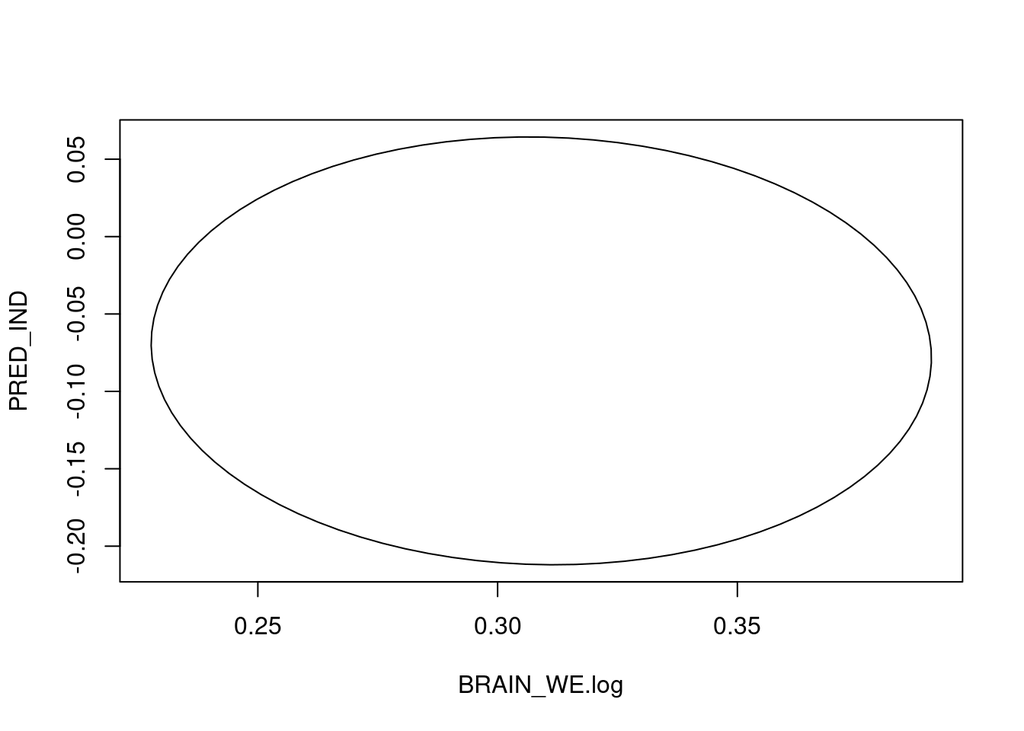

```r
library(ellipse)
plot(ellipse(model5.num, which = c(2, 3), level = 0.95), type="l")
```

И тот же эллипсоид, но для стандартизированных коэффициентов.

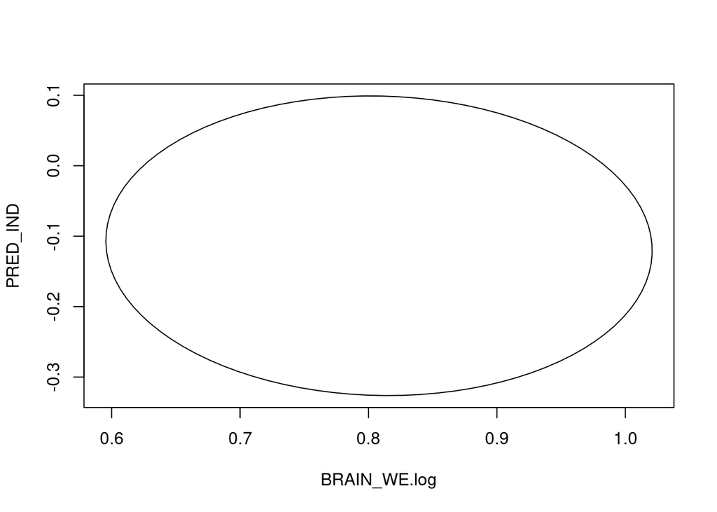

```r
tmp <- dfNew.o.num %>%
  mutate(LIFESPAN.log = scale(LIFESPAN.log), BRAIN_WE.log = scale(BRAIN_WE.log),
         PRED_IND = scale(PRED_IND))
model5.num.scale = lm(LIFESPAN.log~BRAIN_WE.log+PRED_IND, data=tmp)

plot(ellipse(model5.num.scale, which = c(2, 3), level = 0.95), type="l")
```

На эллипсоиде можно заметить, что корреляция между коэффициентами слабая и что коэффициент при BRAIN_WE.log значим, так как его доверительная область далеко от нуля, а доверительная область коэффициента при PRED_IND захватывает 0.

Вспомним, что PRED_IND можно представить как dummy variable. Возможно, зависимость между PRED_IND и LIFESPAN.log не линейная, и модель будет более значимая если представить PRED_IND как dummy variables, чтобы разные его значения могли вносить вклад своими коэффициентами. Посмотрим на зависимость LIFESPAN.log и PRED_IND.

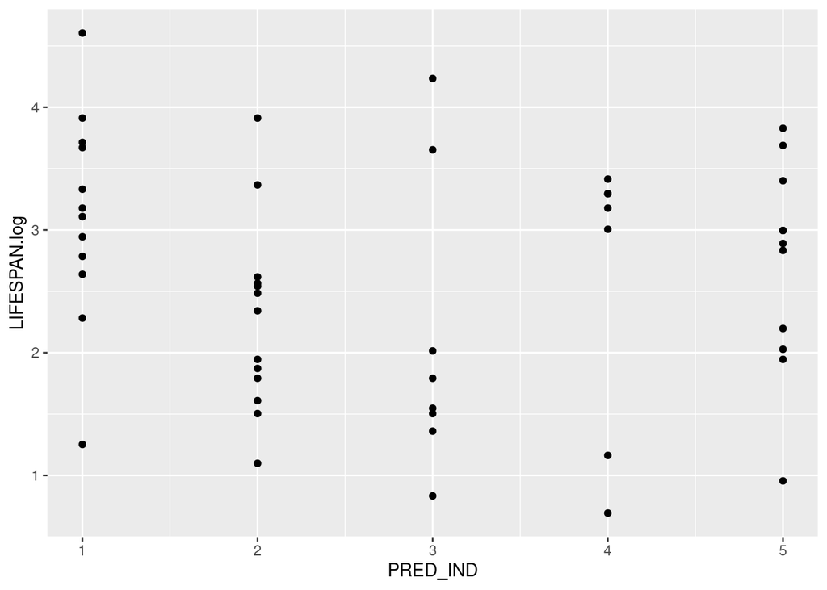

```r
ggplot(dfNew.o.num, aes(x=PRED_IND, y=LIFESPAN.log)) + geom_point()
```

Между признаками есть нелинейная зависимость. Зависимость выглядит как парабола. Давайте посмотрим, какая будет значимость у модели, если PRED_IND сделать dummy variables.

```r
model5.dum = lm(LIFESPAN.log~BRAIN_WE.log+PRED_IND,
            data=mutate(dfNew.o.num, PRED_IND=as.factor(PRED_IND)))
model5.dum.beta <- lm.beta(model5.dum)
summary(model5.dum.beta)
```

```
##
## Call:
## lm(formula = LIFESPAN.log ~ BRAIN_WE.log + PRED_IND, data = mutate(dfNew.o.num,
##     PRED_IND = as.factor(PRED_IND)))
##
## Residuals:
##      Min       1Q   Median       3Q      Max
## -0.92585 -0.26380 -0.05246  0.23261  1.55788
##
## Coefficients:
##              Estimate Standardized Std. Error t value Pr(>|t|)
## (Intercept)   2.03506           NA    0.18733  10.864 3.64e-14 ***
## BRAIN_WE.log  0.29928      0.78248    0.03006   9.958 5.94e-13 ***
## PRED_IND2    -0.48357     -0.22013    0.21441  -2.255 0.029023 *
## PRED_IND3    -0.89342     -0.33938    0.24132  -3.702 0.000581 ***
## PRED_IND4    -0.41017     -0.14743    0.25154  -1.631 0.109943
## PRED_IND5    -0.37814     -0.16246    0.22050  -1.715 0.093237 .
## ---
## Signif. codes:  0 '***' 0.001 '**' 0.01 '*' 0.05 '.' 0.1 ' ' 1
##
## Residual standard error: 0.5282 on 45 degrees of freedom
## Multiple R-squared:  0.7314, Adjusted R-squared:  0.7016
## F-statistic: 24.51 on 5 and 45 DF,  p-value: 7.938e-12
```

9. Теперь попробуем использовать автоматическое удаление критериев.

Проведем backward AIC для данных без и с dummy variables.

```r
library(MASS)
model1.num.AIC <- lm(LIFESPAN.log~BODY_WEI.log+BRAIN_WE.log+SLEEP+GESTTIME.log+PRED_IND+EXP_IND+DANG_IND,
                data=dfNew.o.num)
stepAIC(model1.num.AIC, direction="backward")
```

```
## Start:  AIC=-57.54
## LIFESPAN.log ~ BODY_WEI.log + BRAIN_WE.log + SLEEP + GESTTIME.log +
##     PRED_IND + EXP_IND + DANG_IND
##
##                Df Sum of Sq    RSS     AIC
## - GESTTIME.log  1    0.0005 12.059 -59.542
## <none>                      12.059 -57.544
## - SLEEP         1    0.5977 12.656 -57.077
## - EXP_IND       1    0.6390 12.698 -56.911
## - DANG_IND      1    0.8894 12.948 -55.915
## - BODY_WEI.log  1    1.1015 13.160 -55.086
## - PRED_IND      1    1.9337 13.992 -51.959
## - BRAIN_WE.log  1    4.0824 16.141 -44.673
##
## Step:  AIC=-59.54
## LIFESPAN.log ~ BODY_WEI.log + BRAIN_WE.log + SLEEP + PRED_IND +
##     EXP_IND + DANG_IND
##
##                Df Sum of Sq    RSS     AIC
## <none>                      12.059 -59.542
## - SLEEP         1    0.6601 12.719 -58.824
## - EXP_IND       1    0.6839 12.743 -58.729
## - DANG_IND      1    0.8889 12.948 -57.915
## - BODY_WEI.log  1    1.1511 13.210 -56.892
## - PRED_IND      1    1.9587 14.018 -53.866
## - BRAIN_WE.log  1    4.7818 16.841 -44.509
```

```
##
## Call:
## lm(formula = LIFESPAN.log ~ BODY_WEI.log + BRAIN_WE.log + SLEEP +
##     PRED_IND + EXP_IND + DANG_IND, data = dfNew.o.num)
##
## Coefficients:
##  (Intercept)  BODY_WEI.log  BRAIN_WE.log         SLEEP      PRED_IND
##      0.77525      -0.17216       0.45520       0.04334      -0.49803
##      EXP_IND      DANG_IND
##      0.16632       0.43738
```

```r
library(MASS)
model1.dum.AIC <- lm(LIFESPAN.log~BODY_WEI.log+BRAIN_WE.log+SLEEP+GESTTIME.log+PRED_IND+EXP_IND+DANG_IND,
                data=dfNew.o.dum)
stepAIC(model1.dum.AIC, direction="backward")
```

```
## Start:  AIC=-59.35
## LIFESPAN.log ~ BODY_WEI.log + BRAIN_WE.log + SLEEP + GESTTIME.log +
##     PRED_IND + EXP_IND + DANG_IND
##
##                Df Sum of Sq     RSS     AIC
## - EXP_IND       4    0.6056  8.7839 -63.704
## - GESTTIME.log  1    0.0087  8.1869 -61.294
## - BODY_WEI.log  1    0.1779  8.3562 -60.250
## <none>                       8.1782 -59.348
## - DANG_IND      4    2.0942 10.2724 -55.721
## - SLEEP         1    1.3219  9.5001 -53.707
## - BRAIN_WE.log  1    2.3541 10.5323 -48.446
## - PRED_IND      4    4.4281 12.6063 -45.279
##
## Step:  AIC=-63.7
## LIFESPAN.log ~ BODY_WEI.log + BRAIN_WE.log + SLEEP + GESTTIME.log +
##     PRED_IND + DANG_IND
##
##                Df Sum of Sq     RSS     AIC
## - GESTTIME.log  1    0.0723  8.8562 -65.286
## - BODY_WEI.log  1    0.0855  8.8693 -65.211
## <none>                       8.7839 -63.704
## - SLEEP         1    1.3129 10.0968 -58.600
## - DANG_IND      4    3.0155 11.7994 -56.653
## - BRAIN_WE.log  1    2.1445 10.9284 -54.564
## - PRED_IND      4    4.2327 13.0166 -51.646
##
## Step:  AIC=-65.29
## LIFESPAN.log ~ BODY_WEI.log + BRAIN_WE.log + SLEEP + PRED_IND +
##     DANG_IND
##
##                Df Sum of Sq     RSS     AIC
## - BODY_WEI.log  1    0.1124  8.9686 -66.643
## <none>                       8.8562 -65.286
## - SLEEP         1    1.2407 10.0969 -60.600
## - DANG_IND      4    3.2055 12.0618 -57.531
## - BRAIN_WE.log  1    2.8493 11.7055 -53.060
## - PRED_IND      4    4.4290 13.2852 -52.604
##
## Step:  AIC=-66.64
## LIFESPAN.log ~ BRAIN_WE.log + SLEEP + PRED_IND + DANG_IND
##
##                Df Sum of Sq     RSS     AIC
## <none>                       8.9686 -66.643
## - SLEEP         1    1.3450 10.3136 -61.516
## - DANG_IND      4    3.5589 12.5276 -57.599
## - PRED_IND      4    5.4810 14.4497 -50.319
## - BRAIN_WE.log  1   12.6727 21.6413 -23.718
```

```
##
## Call:
## lm(formula = LIFESPAN.log ~ BRAIN_WE.log + SLEEP + PRED_IND +
##     DANG_IND, data = dfNew.o.dum)
##
## Coefficients:
##  (Intercept)  BRAIN_WE.log         SLEEP     PRED_IND2     PRED_IND3
##      1.14216       0.31059       0.07075      -1.51871      -2.52441
##    PRED_IND4     PRED_IND5     DANG_IND2     DANG_IND3     DANG_IND4
##     -2.66148      -2.76805       1.26859       1.97594       2.54795
##    DANG_IND5
##      2.99344
```

Проведем forward AIC для данных без и с dummy variables.

```r
model2.num.AIC <- lm(LIFESPAN.log~1, data=na.omit(dfNew.o.num))
stepAIC(model2.num.AIC, direction="forward", scope=list(upper=model1.num.AIC,lower=model2.num.AIC))
```

```
## Start:  AIC=-2.44
## LIFESPAN.log ~ 1
##
##                Df Sum of Sq    RSS     AIC
## + BRAIN_WE.log  1   30.2482 16.495 -53.566
## + BODY_WEI.log  1   24.9129 21.831 -39.274
## + GESTTIME.log  1   20.9711 25.772 -30.809
## + EXP_IND       1   12.3521 34.391 -16.095
## + SLEEP         1    8.2560 38.488 -10.356
## <none>                      46.744  -2.445
## + DANG_IND      1    0.7016 46.042  -1.216
## + PRED_IND      1    0.3534 46.390  -0.832
##
## Step:  AIC=-53.57
## LIFESPAN.log ~ BRAIN_WE.log
##
##                Df Sum of Sq    RSS     AIC
## + BODY_WEI.log  1   0.98146 15.514 -54.695
## <none>                      16.495 -53.566
## + PRED_IND      1   0.60283 15.893 -53.465
## + SLEEP         1   0.43147 16.064 -52.918
## + DANG_IND      1   0.17238 16.323 -52.102
## + GESTTIME.log  1   0.13112 16.364 -51.973
## + EXP_IND       1   0.04856 16.447 -51.716
##
## Step:  AIC=-54.69
## LIFESPAN.log ~ BRAIN_WE.log + BODY_WEI.log
##
##                Df Sum of Sq    RSS     AIC
## <none>                      15.514 -54.695
## + PRED_IND      1   0.40838 15.105 -54.055
## + SLEEP         1   0.34707 15.167 -53.848
## + EXP_IND       1   0.19127 15.323 -53.327
## + DANG_IND      1   0.07330 15.441 -52.936
## + GESTTIME.log  1   0.05024 15.464 -52.860
```

```
##
## Call:
## lm(formula = LIFESPAN.log ~ BRAIN_WE.log + BODY_WEI.log, data = na.omit(dfNew.o.num))
##
## Coefficients:
##  (Intercept)  BRAIN_WE.log  BODY_WEI.log
##       1.2173        0.4946       -0.1553
```

```r
model1.dum.AIC <- lm(LIFESPAN.log~1, data=na.omit(dfNew.o.dum))
stepAIC(model1.dum.AIC, direction="forward", scope=list(upper=model1.dum.AIC,lower=model2.num.AIC))
```

```
## Start:  AIC=-2.44
## LIFESPAN.log ~ 1
```

```
##
## Call:
## lm(formula = LIFESPAN.log ~ 1, data = na.omit(dfNew.o.dum))
##
## Coefficients:
## (Intercept)
##       2.585
```

Построим регрессионную модель на основе признаков, которые выбрал stepAIC.

```r
model.AIC <- lm(LIFESPAN.log ~ BRAIN_WE.log + PRED_IND + DANG_IND + SLEEP,
                data=dfNew.o.dum)
model.AIC.beta <- lm.beta(model.AIC)
summary(model.AIC.beta)
```

```
##
## Call:
## lm(formula = LIFESPAN.log ~ BRAIN_WE.log + PRED_IND + DANG_IND +
##     SLEEP, data = dfNew.o.dum)
##
## Residuals:
##      Min       1Q   Median       3Q      Max
## -0.77063 -0.26539 -0.00353  0.19299  1.41179
##
## Coefficients:
##              Estimate Standardized Std. Error t value Pr(>|t|)
## (Intercept)   1.14216           NA    0.46926   2.434 0.019494 *
## BRAIN_WE.log  0.31059      0.81206    0.04131   7.518 3.60e-09 ***
## PRED_IND2    -1.51871     -0.69134    0.34694  -4.377 8.39e-05 ***
## PRED_IND3    -2.52441     -0.95894    0.53882  -4.685 3.21e-05 ***
## PRED_IND4    -2.66148     -0.95665    0.68513  -3.885 0.000376 ***
## PRED_IND5    -2.76805     -1.18920    0.72577  -3.814 0.000464 ***
## DANG_IND2     1.26859      0.56208    0.36878   3.440 0.001374 **
## DANG_IND3     1.97594      0.75060    0.62470   3.163 0.002978 **
## DANG_IND4     2.54795      1.01459    0.71055   3.586 0.000904 ***
## DANG_IND5     2.99344      1.07597    0.84755   3.532 0.001056 **
## SLEEP         0.07075      0.34240    0.02889   2.449 0.018793 *
## ---
## Signif. codes:  0 '***' 0.001 '**' 0.01 '*' 0.05 '.' 0.1 ' ' 1
##
## Residual standard error: 0.4735 on 40 degrees of freedom
## Multiple R-squared:  0.8081, Adjusted R-squared:  0.7602
## F-statistic: 16.85 on 10 and 40 DF,  p-value: 2.169e-11
```

10. Проверим нормальность остатков.

```r
shapiro.test(residuals(model5.dum.beta))
```

```
##
##  Shapiro-Wilk normality test
##
## data:  residuals(model5.dum.beta)
## W = 0.92324, p-value = 0.002768
```

С уровнем значимости 0.05 гипотеза нормальности отвергается.

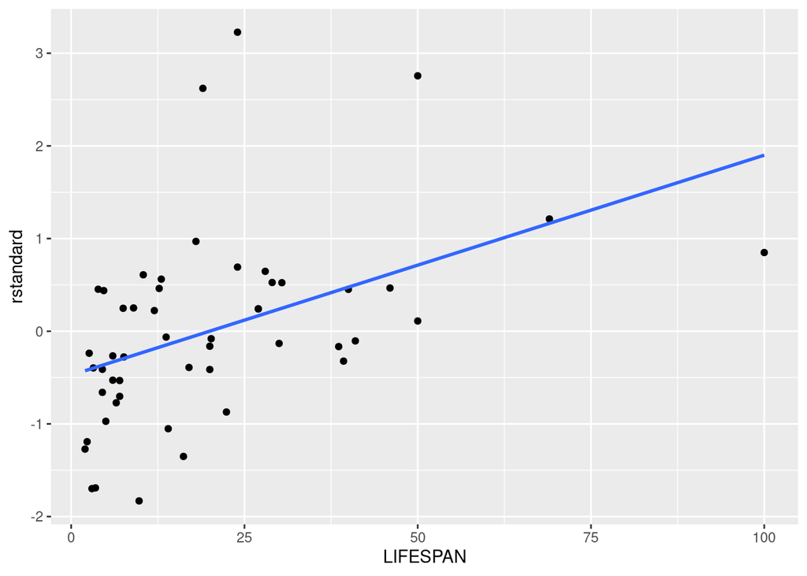

```r
library(olsrr)

tmp <- data_frame(LIFESPAN=dfNew.o.dum$LIFESPAN, rstandard=rstandard(model5.dum))
ggplot(tmp, aes(x=LIFESPAN, y=rstandard)) +
  geom_point() +
  geom_smooth(method=lm, se=FALSE)
```

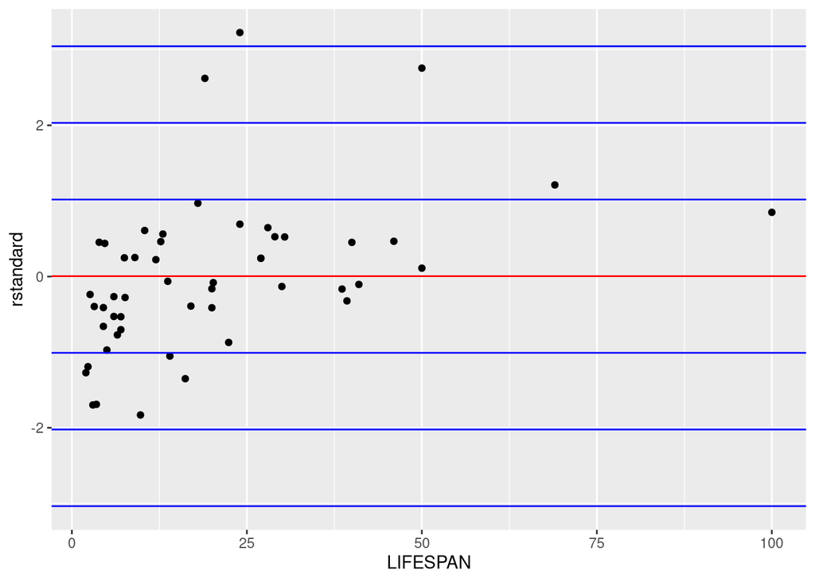

```r
mean <- mean(tmp$rstandard)
std <- sqrt(var(tmp$rstandard))

ggplot(tmp, aes(x=LIFESPAN, y=rstandard)) +
  geom_point() +
  geom_hline(yintercept=mean, color = "red") +
  geom_hline(yintercept=mean-std, color = "blue") +
  geom_hline(yintercept=mean-2*std, color = "blue") +
  geom_hline(yintercept=mean-3*std, color = "blue") +
  geom_hline(yintercept=mean+std, color = "blue") +
  geom_hline(yintercept=mean+2*std, color = "blue") +
  geom_hline(yintercept=mean+3*std, color = "blue")
```

Есть один индивид за 3 сигмы от центра и два индивида за 2 сигмы, посмотрим кто это.

```r
dfNew.o.num[tmp$rstandard > mean+2*std | tmp$rstandard < mean-2*std,]$NAME
```

```
## [1] "Big brown bat"    "Echidna"          "Little brown bat"
```

Большая летучая коричневая мышь, ехидна, маленькая летучая коричневая мышь.

11. Посмотрим на Residuals vs Deleted Residuals plot. Красная линия - это линия y=x, а синия линий - это линия регрессии.

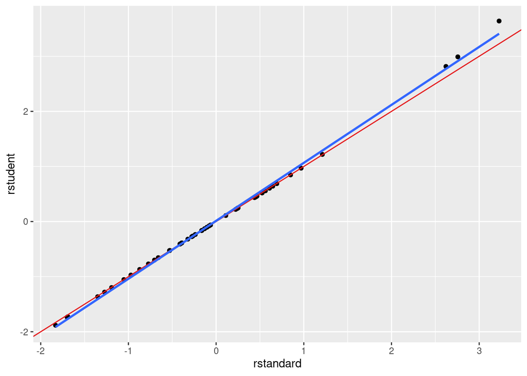

```r
df.rs <- data_frame(rstandard=rstandard(model5.dum), rstudent=rstudent(model5.dum))
ggplot(df.rs, aes(x=rstandard, y=rstudent)) +
  geom_point() +
  geom_abline(slope=1, intercept=0, color='#E41A1C') +
  geom_smooth(method=lm, se=FALSE)
```

Выбросов относительно регрессии нет.

11. Растояние Махаланобиса.

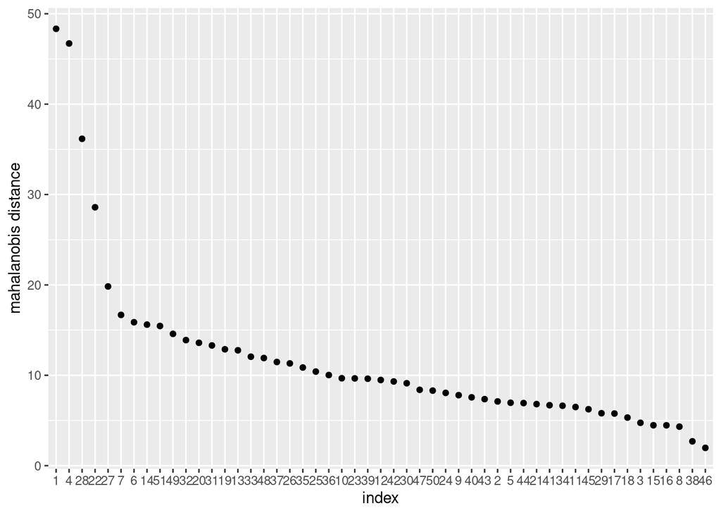

```r
library(rstatix)
mahal <- dfNew.o.num %>%
         dplyr::select(-NAME) %>%
         mahalanobis_distance() %>%
         mutate(index = 1:nrow(dfNew.o.num))

ggplot(mahal) + geom_point(aes(x=reorder(index, -mahal.dist), y=mahal.dist)) +
  ylab("mahalanobis distance") +
  xlab("index")
```

Посмотрим на топ 4 индивида, они выбиваются из остальных.

```r
dfNew.o.num[c(1,4,28,22),]$NAME
```

```
## [1] "African elephant" "Asian elephant"   "Man"              "Ground squirrel"
```

Так и предполагалось, что слоны проявятся как выбросы при подсчете растояния Махаланобиса.

Растояние Кука.

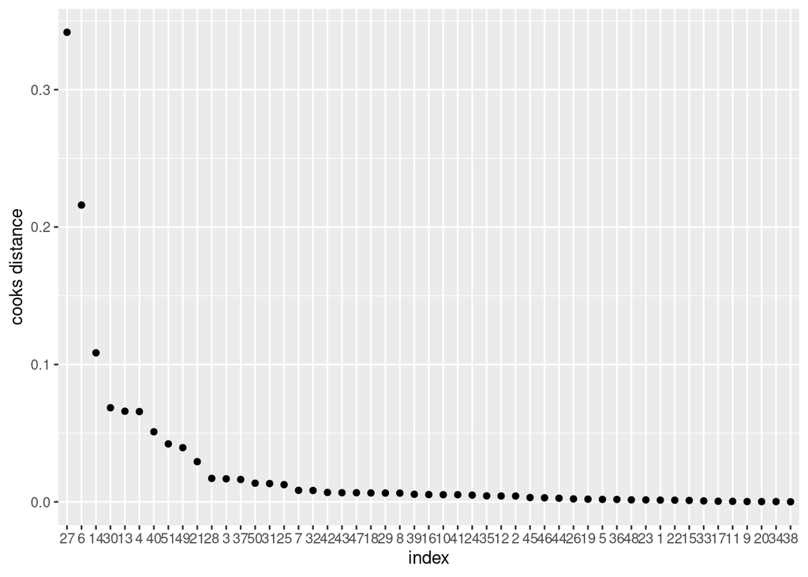

```r
cook <- dfNew.o.num %>%
  mutate(cooks.distance = cooks.distance(model5.dum), index = 1:nrow(dfNew.o.num))

ggplot(cook) + geom_point(aes(x=reorder(index, -cooks.distance), y=cooks.distance)) +
  ylab("cooks distance") +
  xlab("index")
```

Посмотрим на топ 2 индивидов.

```r
dfNew.o.num[c(6,27),]$NAME
```

```
## [1] "Big brown bat"    "Little brown bat"
```

Проверим где на geopm_point находятся летучие мыши и логично ли, что они проявились как выбросы по растоянию Кука.

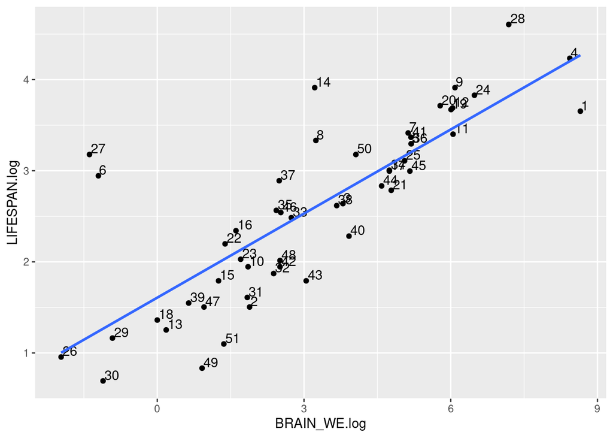

```r
ggplot(dfNew.o.num, aes(x=BRAIN_WE.log, y=LIFESPAN.log, label=1:nrow(dfNew.o.num)))+
  geom_point() +
  geom_text(hjust=-0.1, vjust=-0.1) +
  geom_smooth(method=lm, se=FALSE)
```

Действительно, так и есть. 6 и 27 это мыши и они выбросы относительно линии регрессии.

# Предсказание продолжительности жизни капибар.

На деле капибары живут 8-10 лет на воле и 10-12 в неволе. У капибар не много врагов в природе, но и на вершину пищевой цепи их не поставить, пусть PRED_IND будет равен 3. Средний вес мозга у капибары 76 грамм.

```r
new <- data_frame(BRAIN_WE.log=c(log(76)), PRED_IND=c(3)) %>% mutate(PRED_IND = as.factor(PRED_IND))
exp(predict.lm(model5.dum, new, interval = "prediction"))
```

```
##       fit      lwr      upr
## 1 11.4471 3.697111 35.44285
```

Удалось предсказать время жизни капибры по весу мозга и предположению о ее индексе опасности.